# Analiza bitcoina

Andrej Sokolič

28 avgust 2018

## 1. Tema

V svojem projektu bom analiziral gibanje cene najbolj popularne kriptovalute bitcoin(v nadaljevanju BTC). Izbral bom podatke s katerimi bom opisal dnevno gibanje raznih lastnosti trgovanja z BTC kot so: cena, število transakcij, volumen transakcij, volumen celotnega števila BTC. Poleg časovnega gibanja bomo analizirali tudi število BTC bankomatov po državah in trgovanje z BTC po valutah.

## 2. Uvoz, čiščenje in obdelava podatkov

Podatke sem dobil v HTML obliki na spletni strani https://coinatmradar.com/countries/ in v CSV obliki na https://www.blockchain.com/charts (ogled 26.8.2018) in https://data.bitcoinity.org/markets/volume/30d?c=e&t=b (ogled 26.8.2018).

Podatke iz virov sem uvozil v tri ločene tabele: atm, BTC in val. Nato sem jih prečistil in v naslednjih fazah tudi združil za namene vizualizacije in analize. Tabeli BTC in val prikazujeta dnevno gibanje raznih lastnostih valute in trgovanja z njo v preteklem letu oz. polletju. Bolj kot dnevni promet nas bo zanimal skupen promet v BTC po valutah v zadnjem polletju, ki ga shranimo v novo tabelo Skup_promet. V tabeli atm pa imamo podana števila lokacij bitcoin bankomatov po državah.

1. `BTC`
- `Datum`
- `Cena`
- `Tržna kapitalizacija`
- `Število transakcij`
- `Skupno število transakcij`
- `Promet (v BTC)`
- `BTC v obtoku`
2. `Skup_promet`
- `Valuta`
- `Promet (v BTC)`
3. `atm`
- `Država`
- `Število lokacij`

## Analiza in vizualizacija podatkov

Pridobljene podatke za lažje razumevanje prikažemo v grafih. Pogledamo si spreminjanje cene, števila transakcij, prometa, porazdeljenost lokacij bankomatov po evropskih državah. Ker je bitcoin decentralizirana valuta, je njegova cena odvisna zgolj od povpraševanja in ponudbe, na kar pa vpliva ogromno dejavnikov. Zato je napodedovanje njegove cene praktično nemogoče in je njegova cena zelo nestabilna, kar tudi pokažemo s podatki iz preteklega leta. Bolj zanimivo je pogledati kako se promet ali pa število transakcij spreminja v odvisnosti od cene.

Da je cena res zelo spremenljiva pričajo naslednji podatki o najnižji, najvišji ceni in standardnemu odklonu cene:

| Najnižja cena | Najvišja cena | Standardni odklon cene |
| --- | --- | --- |
| 3319.63 | 19498.68 | 3239.805 |

Pregled cene skozi celo leto prikažemo v grafu:

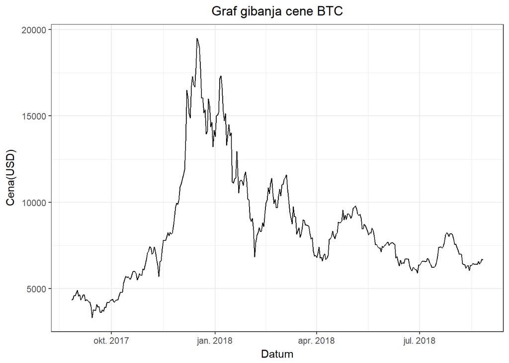

In še gibanje dnevnega števila transakcij, ki v resnici tudi precej niha. Opazimo, da število transackcij vsakih nekaj dni pade. Največ trgovanja se zgodi med tednom, nato število transakcij za vikend precej vpade.

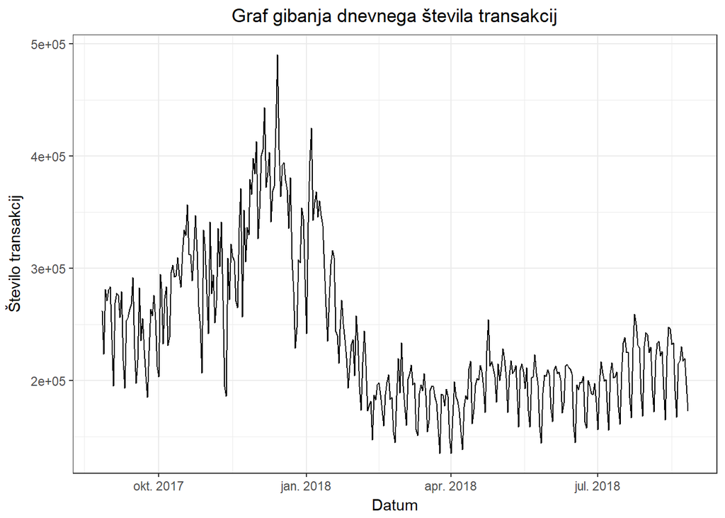

Vidimo, da sta si grafa na prvi pogled precej podobna. Poglejmo si sedaj še točkast graf števila transakcij glede na ceno in regresijsko funkcijo skozi podatke.

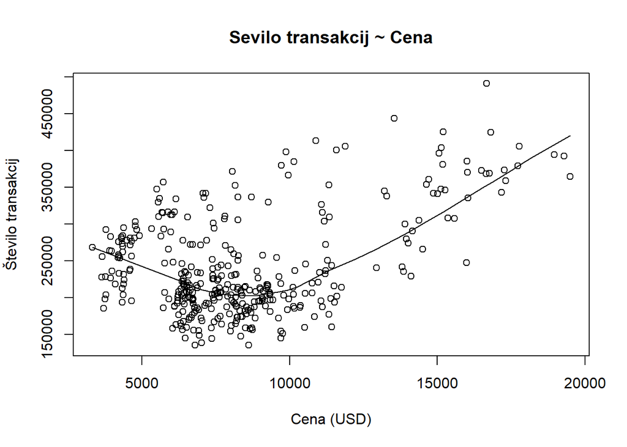

Zanimivo je, da je povezava med številom transakcij in ceno pozitivna za višje cene bitcoina in negativna za nižje cene. Korelacija za podatke, ko je cena nižja od 8000 USD je -0.32, ko je višja od 8000 USD pa kar 0.7.

V spodnjem zemljevidu je prikazano število lokacij BTC bankomatov v nekaterih evropskih državah, ki so obarvane z rumenkasto ali vijolično barvo.

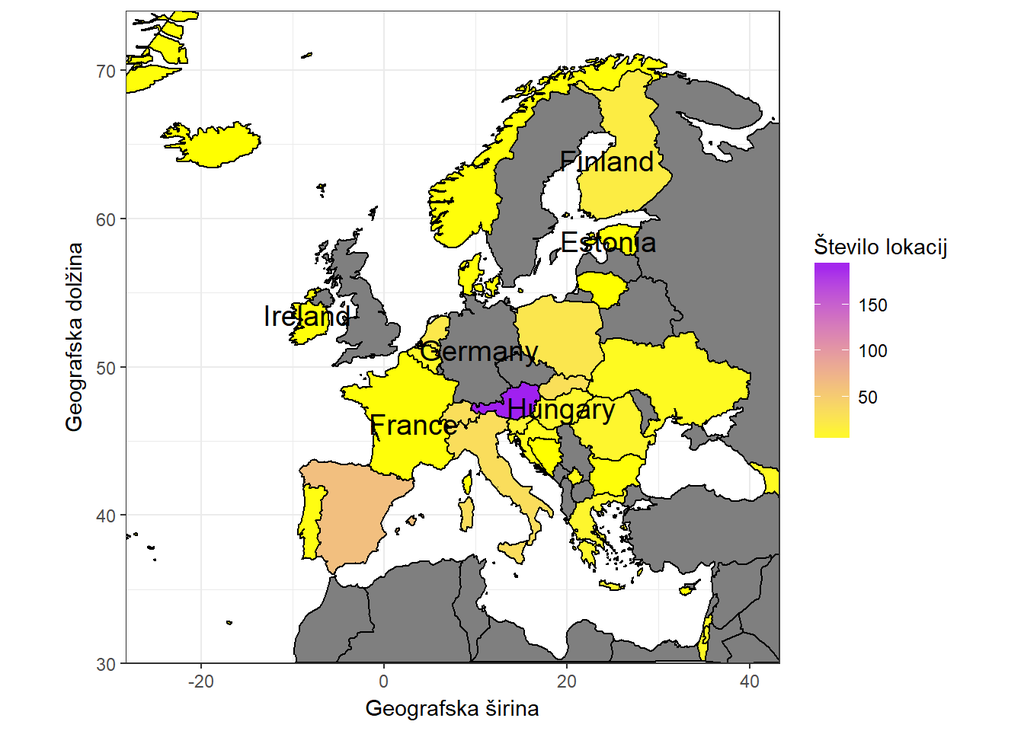

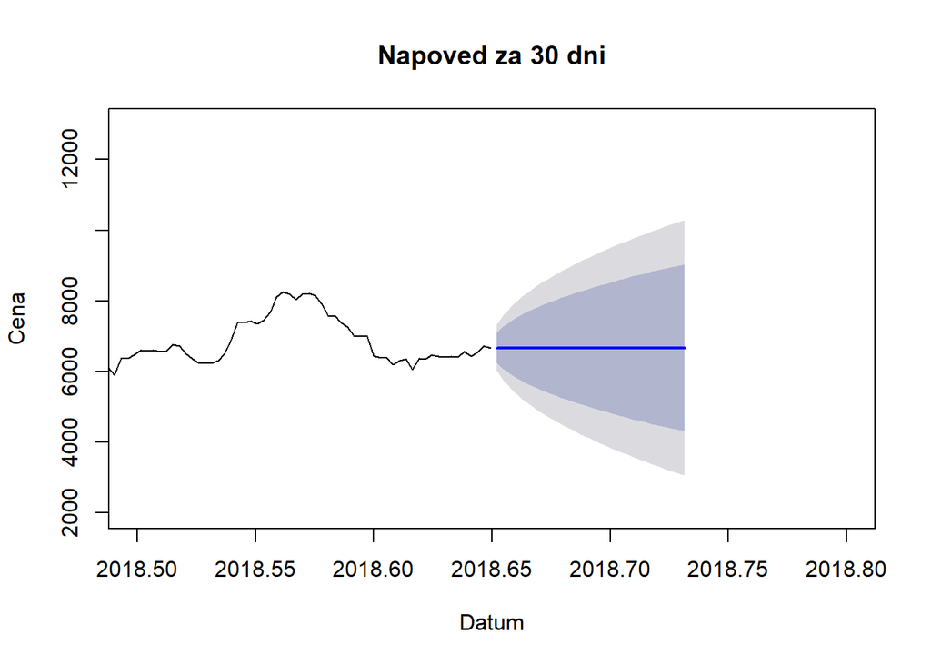